# Symulacje – wybrane artykuły

# 1 Artykuł Kim i Wang (2018)

## 1.1 Omówienie

$$\begin{aligned}
X_1 & \sim N(1,1), \\
X_2 & \sim Exp(1), \\
\epsilon & \sim N(0,1).
\end{aligned}$$

- Następnie wygenerowano dwie zmienne celu $Y_1$ i $Y_2$ według następujących modeli

$$\begin{aligned}
Y_1 & = 1 + X_1 + X_2 + \epsilon, \\
Y_2 & = 0.5(X_1-0.5)^2 + X_2 + \epsilon.
\end{aligned}$$

- Identyfikator $\delta_i$ wylosowano z rozkładu Bernoullego zgodnie z prawdopodobieństwem $p_i$ danym dwoma wzorami:

$$\begin{aligned}
\text{logit}(p_1) & = X_2, \quad \text{ czyli} \frac{\exp(X_2)}{1 + \exp(X_2)}, \\
\text{logit}(p_2) & = -0.5 + 0.5(X_2-2)^2, \quad \text{czyli} \frac{\exp(-0.5 + 0.5(X_2-2)^2)}{1 + \exp(-0.5 + 0.5(X_2-2)^2)}.
\end{aligned}$$

## 1.2 Implementacja w R

Generowanie danych

```r
set.seed(1234567890)
N <- 1e6 ## 1000000
x1 <- rnorm(n = N, mean = 1, sd = 1)
x2 <- rexp(n = N, rate = 1)
epsilon <- rnorm(n = N) # rnorm(N)
y1 <- 1 + x1 + x2 + epsilon
y2 <- 0.5*(x1 - 0.5)^2 + x2 + epsilon
p1 <- exp(x2)/(1+exp(x2))
p2 <- exp(-0.5+0.5*(x2-2)^2)/(1+exp(-0.5+0.5*(x2-2)^2))
populacja <- data.frame(x1,x2,y1,y2,p1,p2)
head(populacja)
```

```
          x1         x2       y1        y2        p1        p2
1  2.3459245 0.59232719 4.665497 3.0232908 0.6438989 0.6202881
2  1.9952713 1.07629265 2.868203 0.9908496 0.7457918 0.4816626
3  1.5462269 1.04162197 3.660954 1.6620227 0.7391628 0.4898125
4 -0.9127239 0.04528219 1.085905 1.9965235 0.5113186 0.8038386
5  2.9212843 2.61316303 7.679682 6.6897064 0.9317039 0.4226228
6  2.3719139 0.82729108 4.725411 3.1055276 0.6957818 0.5467687
```

Losowanie przynależności do big data

```r
set.seed(123)
flag_bd1 <- rbinom(n = N, size = 1, prob = populacja$p1)
table(flag_bd1)
```

```
flag_bd1
     0      1
306701 693299
```

oraz oszacowanie $\bar{y}$ na podstawie big data

```r
c("big data"=mean(populacja[flag_bd1 == 1, "y1"]), "wartość prawdziwa" = mean(y1))
```

```
         big data wartość prawdziwa
         3.182722          2.995707
```

## 1.3 Przyjrzyjmy się danym

Rozkład X2

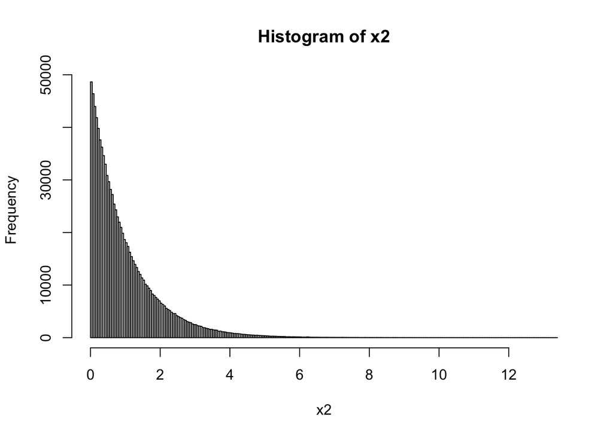

```r
hist(x2, breaks = "scott")
```

Zależność między $X_1$, a $Y_2$

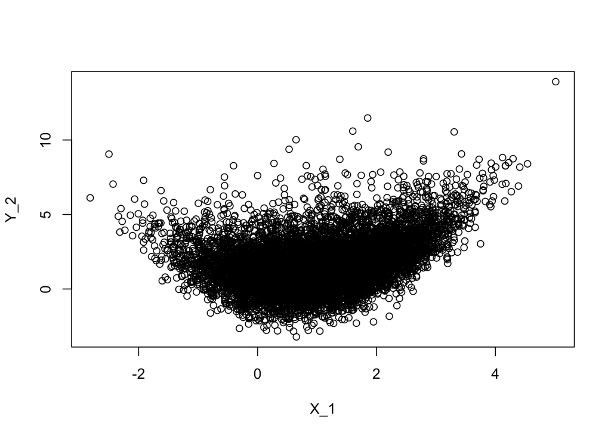

```r
## ograniczam liczbę punktów bo jest ich bardzo dużo (biorę 10k)
set.seed(1234)
los <- sample(1:N,10000, replace = F)
plot(x1[los], y2[los],
     xlab = "X_1",
     ylab = "Y_2")
```

Histogram $p_1$ i $p_2$

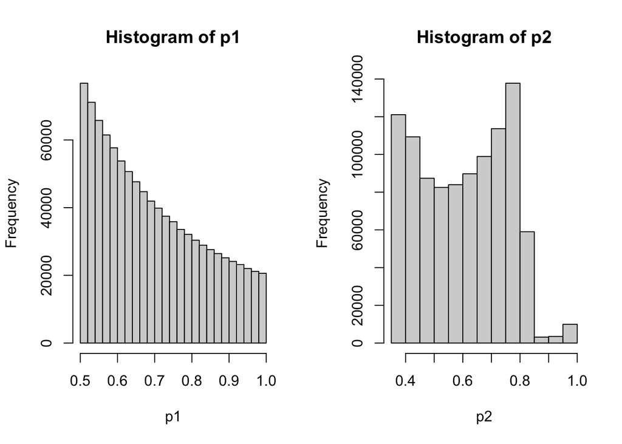

```r
par(mfrow = c(1,2))
hist(p1)
hist(p2)
```

Wykresy funkcji dla $p_1$ i $p_2$

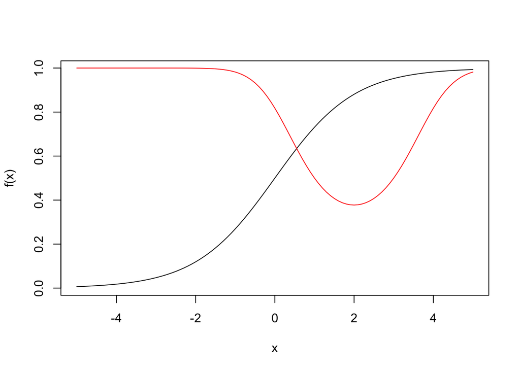

```r
curve(expr = exp(x)/(1+exp(x)),
      from = -5, to = 5,
      ylab = "f(x)")
curve(expr = exp(-0.5+0.5*(x-2)^2)/(1+exp(-0.5+0.5*(x-2)^2)),
      from = -5, to = 5,
      add = TRUE,
      col = "red",
      ylab = "")
```

# 2 Artykuł Yang, Kim, i Song (2020)

## 2.1 Omówienie

Autorzy zakładają populację składającą się ze zmiennych $X$ oraz $Y$ daną

$$\mathcal{F}_{N}=\left\{\left(X_{i}, Y_{i}\right): i=1, \ldots, N\right\},$$

gdzie wielkość populacji to $N=10000$, $Y_{i}$ może być zmienną ciągłą lub dyskretną oraz

$$X_{i}=\left(1, X_{1, i}, \ldots, X_{p-1, i}\right)^{\mathrm{T}},$$
jest $p$-wymiarowym wektorem zmiennych pomocniczych ze stałą 1 na pirwszym miejscu, a pozostałe zmienne zostały wyngernowane z rozkładu normalnego standaryzowanego. Autorzy ustalili liczbę zmiennych na $p=50$.

From the finite population, we select a non-probability sample $\mathcal{B}$ of size $n_{\mathrm{B}} \approx 2000$, according to the selection indicator $I_{\mathrm{B}, i} \sim$ Ber $\left(\pi_{\mathrm{B}, i}\right)$.

We select a probability sample $\mathcal{A}$ of the average size $n_{\mathrm{A}}=500$ under Poisson sampling with

$$\pi_{\mathrm{A}, i} \propto\left(0.25+\left|X_{1 i}\right|+0.03\left|Y_{i}\right|\right).$$

The parameter of interest is the population mean $\mu=N^{-1} \sum_{i=1}^{N} Y_{i}$.

For the non-probability sampling probability, we consider both linear and non-linear sampling score models:

- $\operatorname{logit}\left(\pi_{\mathrm{B}, i}\right)=\alpha_{0}^{\mathrm{T}} X_{i}$, where $\alpha_{0}=(-2,1,1,1,1,0,0,0, \ldots, 0)^{\mathrm{T}}$ (model PSM I);
- $\operatorname{logit}\left(\pi_{\mathrm{B}, i}\right)=3.5+\alpha_{0}^{\mathrm{T}} \log \left(X_{i}^{2}\right)-\sin \left(X_{3, i}+X_{4, i}\right)-X_{5, i}-X_{6, i}$, where $\alpha_{0}=(0,0,0,3,3,3,3$, $0, \ldots, 0)^{\mathrm{T}}$ (model PSM II).

For generating a continuous outcome variable $Y_{i}$, we consider both linear and non-linear outcome models with $\beta_{0}=(1,0,0,1,1,1,1,0, \ldots, 0)^{\mathrm{T}}$ :

For generating a binary outcome variable $Y_{i}$, we consider both linear and non-linear outcome models with $\beta_{0}=(1,0,0,3,3,3,3,0, \ldots, 0)^{\mathrm{T}}$,

- $Y \sim \operatorname{Ber}\left\{\pi_{Y}(X)\right\}$ with logit $\left\{\pi_{Y}(X)\right\}=\beta_{0}^{\mathrm{T}} X$ (model OM III);
- $Y \sim \operatorname{Ber}\left\{\pi_{Y}(X)\right\}$ with logit $\left\{\pi_{Y}(X)\right\}=2-\log \left\{\left(\beta_{0}^{\mathrm{T}} X\right)^{2}\right\}+2 X_{5, i}+2 X_{6, i}$ (model OM IV).

## 2.2 Implementacja

```r
library(sampling) ## inclusionprobabilities + UPpoisson
set.seed(1234567890)
N <- 10000
p <- 50
n_A <- 500
X <- matrix(rnorm(N * (p-1)), ncol = p-1)
X <- cbind(rep(1, N), X)

## parametry beta i alpha
beta0 <- c(1, 0, 0, 1, 1, 1, 1, rep(0, p-7))
alpha0 <- c(-2, 1, 1, 1, 1, rep(0, p-5))
alpha1 <- c(0, 0, 0, 3, 3, 3, 3, rep(0, p-7))

## y variables
epsilon <- rnorm(N)
Y_OM1 <- X %*% beta0 + epsilon
Y_OM2 <- 1 + exp(3*sin(X %*% beta0)) + X[, 6] + X[, 5] + epsilon
pi_Y_OM3 <- as.numeric(plogis(X %*% beta0))
pi_Y_OM4 <- as.numeric(plogis(2-log((X %*% beta0)^2) + 2*X[,6] + 2*X[,7]))
Y_OM3 <- rbinom(N, size = 1, prob = pi_Y_OM3)
Y_OM4 <- rbinom(N, size = 1, prob = pi_Y_OM4)

## nonprob
pi_B_PMS1 <- as.numeric(plogis(X %*% alpha0))
pi_B_PMS2 <- as.numeric(plogis(3.5 + log(X^2) %*% alpha0 - sin(X[,4] + X[,5]) - X[,6]- X[,7]))

## prob
pi_A_Y_OM1 <- inclusionprobabilities(0.25 + abs(X[, 2]) + 0.03*abs(Y_OM1), n_A)
pi_A_Y_OM2 <- inclusionprobabilities(0.25 + abs(X[, 2]) + 0.03*abs(Y_OM2), n_A)
pi_A_Y_OM3 <- inclusionprobabilities(0.25 + abs(X[, 2]) + 0.03*abs(Y_OM3), n_A)
pi_A_Y_OM4 <- inclusionprobabilities(0.25 + abs(X[, 2]) + 0.03*abs(Y_OM4), n_A)
```

## Bibliografia

Kim, Jae Kwang, i Zhonglei Wang. 2018. „Sampling Techniques for Big Data Analysis”. *International Statistical Review* 87 (S1): S177–91. https://doi.org/10.1111/insr.12290.

Yang, Shu, Jae Kwang Kim, i Rui Song. 2020. „Doubly Robust Inference When Combining Probability and Non-Probability Samples with High Dimensional Data”. *Journal of the Royal Statistical Society Series B: Statistical Methodology* 82 (2): 445–65. https://doi.org/10.1111/rssb.12354.